# NYC Citi Bike Data Analysis

Prathiba

30/08/2021

# 1. Documentation

#### Domain knowledge (1.1)

Citi Bike is New York City’s bike share system, and the largest in the nation. Citi Bike launched in May 2013 and has become an essential part of the transportation network. It’s fun, efficient and affordable. The bikes can be unlocked from one station and returned to any other station in the system, making them ideal for one-way trips.Citi Bike is available for use 24 hours/day, 7 days/week, 365 days/year. You can read more about the company the data comes from on the [NYC Citi Bike website](https://www.citibikenyc.com/about)

#### Business requirements (1.2)

The bike sharing system is becoming more popular in the process of greener initiative. This report helps to

- Understand the pattern of bike hires over a period of time to identify when it is widely used.
- Analyse the pattern of bike hires with respect to the rider demographics such as age, gender or the type of the user.
- Identify the geographical spread of the starting points of bike hires

#### Business processes and data flow (1.3)

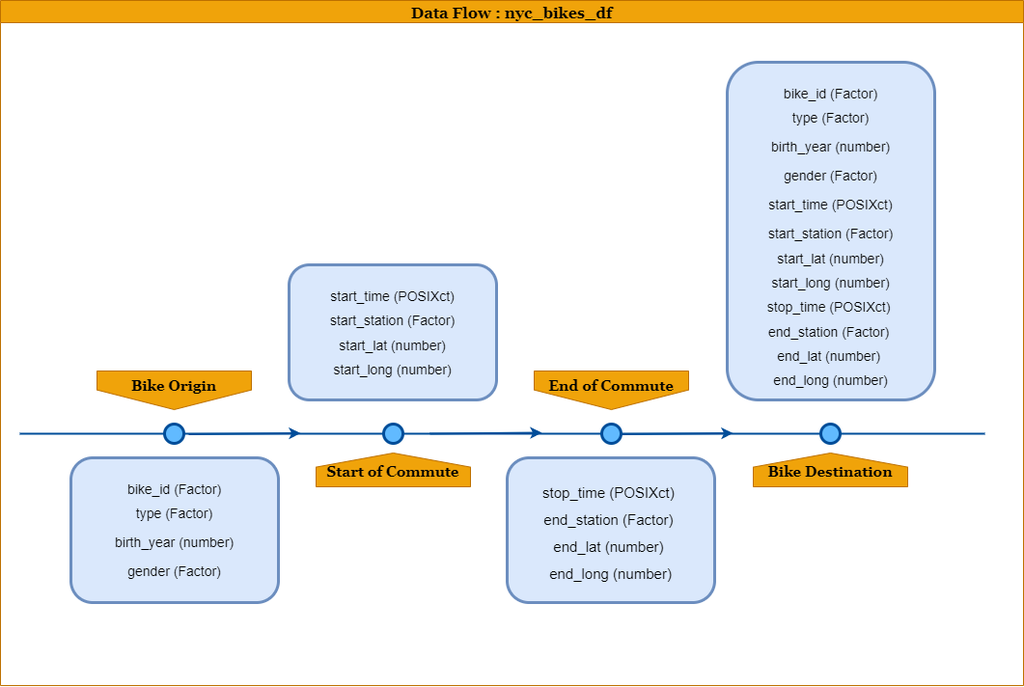

This diagram was created using draw.io at https://app.diagrams.net

#### Data visualisation as a tool for decision-making (1.4)

One of the main challenges in the bike sharing system is to effectively plan the resource usage. This report helps to visualise the traffic level at each station on a daily basis. Based on the traffic level, the demands can be predicted and the number of available bikes at that station can be intepreted or forecasted.

#### Data types (1.5)

| Attributes | Description | Data Types |
| --- | --- | --- |
| bike_id | Unique ID for the bike | Factor |
| start_time | Starting time from the origin | POSIXct |
| stop_time | Ending Time at the destination | POSIXct |
| start_station | Origin Station | Factor |
| start_lat | Origin Station’s Latitude | Number |
| start_long | Origin Station’s Longitude | Number |
| end_station | Destination Station | Factor |
| end_lat | Destination Station’s Latitude | Number |
| end_long | Destination Station’s Longitude | Number |
| type | Type of user | Factor |
| birth_year | Birth Year of the user | Number |
| gender | Gender of the user | Factor |

#### Data quality and data bias (1.6)

The dataset description says, **" A sample from NYC Citi Bike usage of 10 bikes throughout 2018"** which may result in *selection bias*. However we assumed that the sample seeks to accurately reflect the characteristics of the larger group and hence doesn’t affect the quality of the data.

# 2. Data cleaning

#### Preparing data for visualisation (1.7)

- The time attributes like month, week, day & year are derived from the start time.
- The gender with type “Unknown” are considered as NA as a part of cleaning process.

# 3. Data visualisation

#### Process and design (2.1, 2.7, 2.8, 2.9)

First, I investigated the bike hire pattern with simple line chart starting with year and later aggregated with month to identify when it is widely used. Then I analysed the bike hire pattern with respect to the rider demographics such as age, gender or the type of the user to see if there were any relation. I have also represented the geographical spread using spatial plots with cluster option. I ensured that the key visualizations are accurate and depicts the clear understanding of the requirement and not misleading. I also wanted to convey that the plots were aesthetically pleasing. All visualizations were made in RStudio using the ggplot and leaflet package.

#### Visualisations (2.2, 2.3, 2.4, 2.5, 2.6)

### *Understand the pattern of bike hires over a period of time*

Let’s first analyse the bike hire pattern over year.

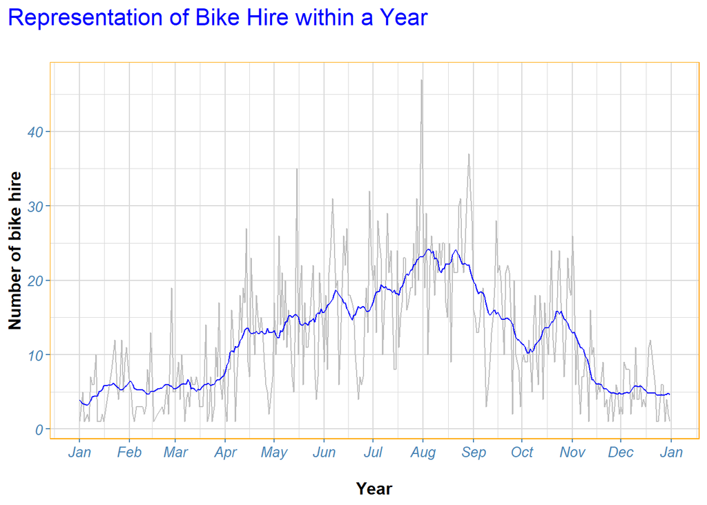

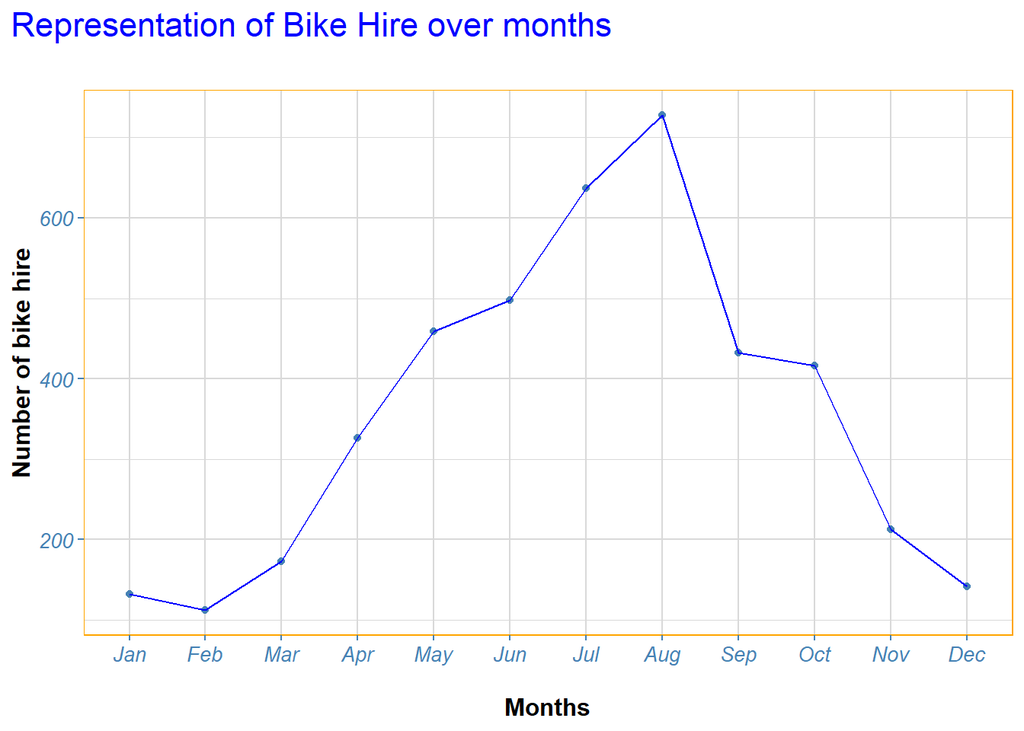

This shows that the bike is hired predominantly from Spring to Autumn, with highest being the Summer time.

Let’s further explore the usage of bike over the weeks. Since the number of bike hire is predominantly high between June and August, let’s visualise the data for those month,

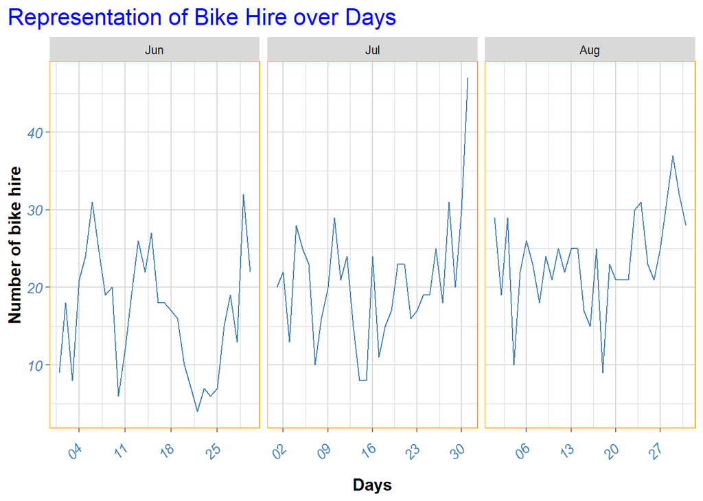

### *Analyse the pattern of bike hires with respect to the rider demographics*

Let’s check the hire patterns between the bike riders based on gender and the type of bike rider.

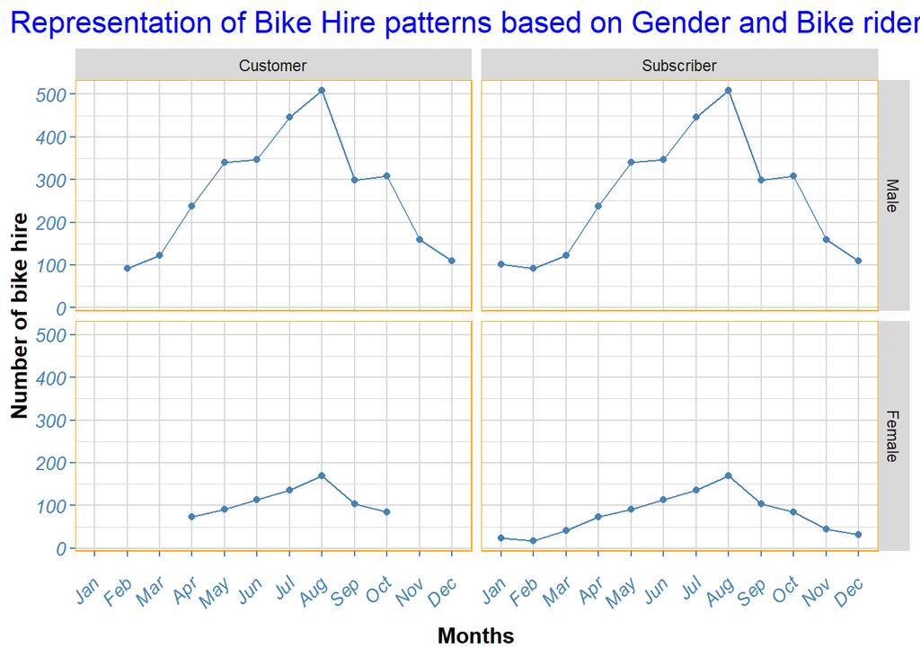

This line plot is a overall representation of the bike hire patterns based on gender and type of bike rider over a period of 12 months for the year 2018.

Let’s explore which age group hire more bikes

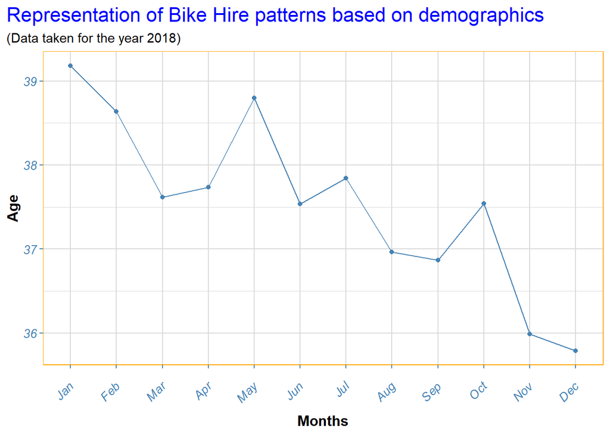

The above line chart shows that on an average, riders between age 36 and 38 hire often.

To summarise, though the bike rider’s demographics doesn’t seems to have a direct impact on the hire pattern, they are dependent to each other.

### *Identify the geographical spread of the starting points of bike hires*

Now we understood the maximum usage of the bike hire pattern and analysed with respect to the rider demographics, let’s analyze the busiest station on a daily basis. It is calculated based on the total number of bike hire per day. This measure helps to identify the traffic level of a particular station.

Since there are more bike hires between June and August, Let’s visualize those data using map based display.

[interactive chart not shown]

The map shows the location of each station grouped with markers together (called as clusters) . Each cluster is identified by its color scale which really helps to visualize the number of bike hire (check-in) at that station. The orange circle indicates the busier station with green being, comparatively lowest traffic level. Based on that, the Jersey City seems to have the busiest traffic,especially Groove Street (to be precise). This helps to give an estimate of how to forecasts the future demand. ie. the minimum available number of bikes at that station.

**Conclusion:**

To conclude, these results provide a framework for the business planners to assess the current process and to develop more prediction analysis on the number of available bikes at any given station.

**Other Insights:**

- In our analysis, if we narrow down further to hours the bike was hired, it might help to identify the busiest timings of the day. It gives a better view to optimize the availability of bikes.
- Adding weather conditions to our analysis might give a different insights on the rider’s perspective.